# A closer look at the China-US trade

Martin Geissmann

5/27/2019

# What we shall answer

- What’s the total annual US import and export?
- Who are the main trading partners?
- How’s the picture for China? Import and exports?
- A look at the GDP growth
- What type of goods are traded?

# UN Comtrade

[UN Comtrade](https://comtrade.un.org/) is a repository of official international trade statistics and relevant analytical tables. It allows to view and download detailed global trade data, i.e. imports and exports of all goods or even of specific services or goods (say tomatoes).

comtradr is a R package and a collection of functions for interacting with the UN Comtrade API. Besides *comtradr* we use various other packages that we shall load first.

```r
library(tidyverse)
library(comtradr)
library(visNetwork)
library(grid)
library(png)
library(RCurl)
library(scales)


billion <- function(value) {
  value/1000000000
}
```

## How to use comtradr

```r
q <- ct_search(reporters = "USA",
               partners = c("Germany", "France", "Japan", "Mexico"),
               trade_direction = "imports")
```

The main function is `ct_search()`. It accepts the following arguments:

- reporters: Reporting country, can be “All” (required)
  - can use `ct_country_lookup()` to look up the name of a country, e.g. `ct_country_lookup("russia")`
- partners: Partner country, can be "All (required)
- trade_direction: “imports”, “exports”, “re_imports”, “re_exports”. Default value is “all”
- freq: “annual” or “monthly”. Default value is “annual”.
- start_date: “yyyy” if freq=“annual”, or “yyyy-mm” if freq=“monthly”, can be “all” (default)
- end_date: same
- commod_codes: character vector of commodity codes, or “TOTAL” (default)
  - use `ct_commodity_lookup()` to look up codes, e.g. `tomatoes <- ct_commodity_lookup("tomato")`.
  - `tomatoes` can then be used as a variable for the argument
- max_rec: max. number of records, 50’000 without API token, 250’000 with (see also `ct_register_token()`)
- type: “goods” or “services”. Default value is “goods”.
- url: not needed

```r
q %>% glimpse()
```

```
## Observations: 112
## Variables: 35
## $ classification         <chr> "H5", "H5", "H5", "H5", "H5", "H5", "H5",…
## $ year                   <int> 2017, 2017, 2017, 2017, 2018, 2018, 2018,…
## $ period                 <int> 2017, 2017, 2017, 2017, 2018, 2018, 2018,…
## $ period_desc            <chr> "2017", "2017", "2017", "2017", "2018", "…
## $ aggregate_level        <int> 0, 0, 0, 0, 0, 0, 0, 0, 0, 0, 0, 0, 0, 0,…
## $ is_leaf_code           <int> 0, 0, 0, 0, 0, 0, 0, 0, 0, 0, 0, 0, 0, 0,…
## $ trade_flow_code        <int> 1, 1, 1, 1, 1, 1, 1, 1, 1, 1, 1, 1, 1, 1,…
## $ trade_flow             <chr> "Import", "Import", "Import", "Import", "…
## $ reporter_code          <int> 842, 842, 842, 842, 842, 842, 842, 842, 8…
## $ reporter               <chr> "USA", "USA", "USA", "USA", "USA", "USA",…
## $ reporter_iso           <chr> "USA", "USA", "USA", "USA", "USA", "USA",…
## $ partner_code           <int> 251, 276, 392, 484, 251, 276, 392, 484, 2…
## $ partner                <chr> "France", "Germany", "Japan", "Mexico", "…
```

[output cut: 22 more lines]

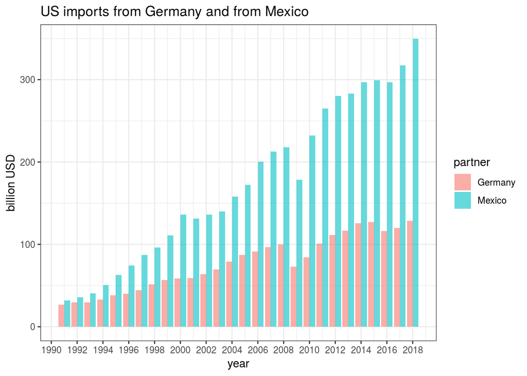

```r
q %>%
  as_tibble() %>%
  filter(reporter == "USA", partner %in% c("Germany", "Mexico")) %>%
  select(trade_value_usd, reporter, partner, everything()) %>%
  ggplot(aes(x = year, y = trade_value_usd/1000000000, fill = partner)) +
  geom_col(alpha = 0.6, position = "dodge") +
  scale_y_continuous(labels = scales::number) +
  scale_x_continuous(breaks = seq(1990, 2018, 2)) +
  labs(title = "US imports from Germany and from Mexico", y = "billion USD") +
  theme_bw()
```

# USA international trade

## Load Comtrade data

```r
us1 <- ct_search(reporters = "USA",
                 partners = "All",
                 trade_direction = c("imports", "exports"),
                 freq = "annual",
                 start_date = (2018-4),
                 end_date = 2018)

us2 <- ct_search(reporters = "USA",
                 partners = "All",
                 trade_direction = c("imports", "exports"),
                 freq = "annual",
                 start_date = (2013-4),
                 end_date = 2013)

us3 <- ct_search(reporters = "USA",
                 partners = "All",
                 trade_direction = c("imports", "exports"),
                 freq = "annual",
                 start_date = (2008-4),
                 end_date = 2008)

us4 <- ct_search(reporters = "USA",
                 partners = "All",
                 trade_direction = c("imports", "exports"),
                 freq = "annual",
                 start_date = (2003-4),
                 end_date = 2003)

us5 <- ct_search(reporters = "USA",
                 partners = "All",
                 trade_direction = c("imports", "exports"),
                 freq = "annual",
                 start_date = (1998-4),
                 end_date = 1998)

us <- bind_rows(us1, us2, us3, us4, us5) %>% distinct()

us %>% saveRDS("data/us.RDS")
```

## Balance of trade

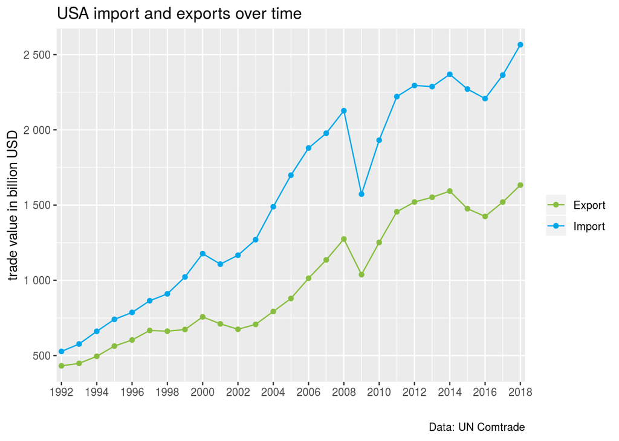

```r
data1 <- us %>% #distinct() %>%
  filter(partner_iso != "WLD") %>%
  mutate(trade_value_usd_bn = billion(trade_value_usd)) %>%
  group_by(trade_flow, year) %>%
  summarise(trade_value_usd_bn = sum(trade_value_usd_bn, na.rm = T))

data1 %>%
  ggplot(aes(x = year, y = trade_value_usd_bn, color = trade_flow)) +
  # geom_area(alpha = 0.1, position = "identity") +
  geom_line() +
  geom_point() +
  scale_y_continuous(labels = scales::number, breaks = seq(0, 2500, 500)) +
  scale_color_manual(values = c("#88be3f", "#02a7eb")) +
  scale_x_continuous(breaks = seq(1990, 2018, 2), expand = c(0.01, 0.01)) +
  labs(title = "USA import and exports over time",
       x = "", y = "trade value in billion USD", caption = "Data: UN Comtrade", color = "", fill = "")
```

In 2018 the balance of trade *in goods* was in deficit by -933

Current account? What about services?

```r
srv <- ct_search(reporters = "USA",
                 partners = "All",
                 trade_direction = c("imports", "exports"),
                 type = "services",
                 freq = "annual",
                 start_date = (2018-4),
                 end_date = 2018)

# srv %>% saveRDS("data/srv.RDS")
```

```r
services <- srv %>% as_tibble() %>%
  filter(partner == "World") %>%
  group_by(year, trade_flow) %>%
  summarise(trade_value_usd_bn = sum(trade_value_usd)/1000000000) %>%
  spread(trade_flow, trade_value_usd_bn)
```

Of course, there’s more to the current account than just the trade in good. There’s trade in services, the countrie’s income abroad, and current transfers. For the former we have the latest data from Cometrade dates from 2016. The US imported services of 496 billion USD while it exported services for 727 bn USD. The surplus here is 231 bn USD.

To put this into perspective, the balance of trade in goods was at -783. The balance of trade goods *and* services would therefore be -552 bn USD (2016).

We shall focus on the exchange of goods in the following.

## Trading partners

Who are the US’ main trading partners?

Prepare a function `trade_plot()` for plotting the trade data.

```r
# function similar to annotation_custom() but specifying data
annotation_custom2 <- function (grob, xmin = -Inf, xmax = Inf,
                            ymin = -Inf, ymax = Inf,
                            data) {
  layer(data = data,
        stat = StatIdentity,
        position = PositionIdentity,
        geom = ggplot2:::GeomCustomAnn,
        inherit.aes = TRUE, params = list(grob = grob,
                                          xmin = xmin, xmax = xmax,
                                          ymin = ymin, ymax = ymax))
}

percent2 <- function(input) {
  if (is.numeric(input)) {
    output <- percent(input)
  } else {
    output <- input
  }
  return(output)
}

number2 <- function(input) {
  if (is.numeric(input)) {
    output <- number(input)
  } else {
    output <- input
  }
  return(output)
}

trade_plot <- function(data, yr = 2018, top_n = 8, include_others = T, include_flags = T, include_share = T, title = "USA import and exports") {

  if (top_n) {
    o <- "Others"
  } else {
    o <- "Rest of the world"
  }

  top_partners <- data %>%
    filter(partner_iso != "WLD", year == year) %>%
    group_by(partner_iso) %>%
    tally(trade_value_usd, sort = T) %>%
    top_n(top_n) %>%
    pull(partner_iso)

  if (include_others) {
    others <- data %>%
      filter(year == yr, !(partner_iso %in% top_partners), partner_iso != "WLD") %>%
      group_by(trade_flow) %>%
      summarise(trade_value_usd = sum(trade_value_usd)) %>%
      mutate(partner_iso = o, partner = o, year = yr)

    toplot <- data %>%
      filter(year == yr, partner_iso %in% top_partners) %>%
      bind_rows(others) %>%
      mutate(partner_iso_fac = factor(partner_iso, levels = c(top_partners, o)))

  } else {
    toplot <- data %>%
      filter(year == yr, partner_iso %in% top_partners) %>%
      mutate(partner_iso_fac = factor(partner_iso, levels = c(top_partners)))
  }

  toplot <- toplot %>%
    ungroup() %>%
    mutate(trade_value_usd_bn = billion(trade_value_usd))

  if (include_share) {
    toplot <- toplot %>%
      group_by(trade_flow) %>%
      mutate(share_of_total = trade_value_usd_bn/sum(trade_value_usd_bn)) %>%
      ungroup()
  } else {
    toplot <- toplot %>%
      mutate(share_of_total = "")
  }


  p <- toplot %>%
    group_by(partner_iso, trade_flow) %>%
    mutate(label_pos = max(trade_value_usd_bn/2, 100)) %>%
    ungroup() %>%
    ggplot(aes(y = trade_value_usd_bn, x = trade_flow, fill = trade_flow)) +
    geom_col() +
    geom_text(aes(label = number(trade_value_usd_bn, big.mark = "'"), y = label_pos), size = 3) +
    geom_text(aes(label = percent2(share_of_total),
                  y = max(trade_value_usd_bn)*0.9), size = 2.5, hjust = -0.2) +
    facet_wrap(~partner_iso_fac, dir = "h",
               nrow = max(1, ceiling(sqrt(top_n)), na.rm = T),
               # ncol = max(1, ceiling((top_n+include_others)/ceiling(sqrt(top_n))), na.rm = T)
               ) +
    scale_fill_manual(values = c("#88be3f", "#02a7eb"))

  if (include_flags) {
    countries_annotate <- toplot %>%
      select(partner_iso, partner) %>%
      distinct() %>%
      mutate(path = paste0("./flags/", str_replace_all(partner, " ", "_"), ".png"))

    max_y <- max(toplot$trade_value_usd_bn, na.rm = T)

    for (i in 1:top_n) {
      if (!top_n) { next() }
      data_annotate <- tibble(partner_iso_fac = factor(countries_annotate[i, "partner_iso"], levels = c(top_partners, o)),
                              trade_flow = "Export", trade_value_usd_bn = 1)
      if (file.exists(pull(countries_annotate[i, "path"]))) {
        # print(paste0(pull(countries_annotate[i, "path"]), " exists and should be plotted"))
        img <- readPNG(pull(countries_annotate[i, "path"]))

        p <- p +
          annotation_custom2(rasterGrob(img, interpolate=TRUE),
                             ymax = max_y, ymin = max_y*0.8,
                             xmin = -1, data = data_annotate)
      } else {
          next()
        }
    }
  }
  p <- p +
    labs(x = "", y = "",
         title = title, subtitle = paste0("trade value in goods in billion USD, year: ", yr),
         caption = "Data: UN Comtrade") +
    theme(legend.position = "none") #+
    # theme_bw()

  return(p)
}
```

Again here’s the total import and exports for the year 2018.

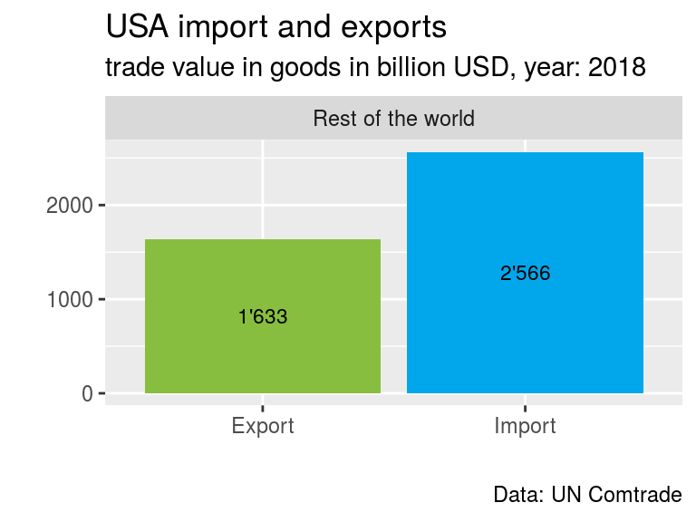

```r
trade_plot(us, top_n = 0, include_others = T, include_flags = T, include_share = F)
```

Let’s see the 24 top trading parters

[figure not shown]

```r
# trade_plot(us, top_n = 25, include_others = F, include_flags = T)

trade_plot(us, top_n = 24, include_others = T, include_flags = T, include_share = T)
```

## Over time

The increase in imports from China is a recent phenomena. It has a lot China economic catching up with the west. See recent history on Wikipedia.

Here’s the imports from the 5 todays major trading partners:

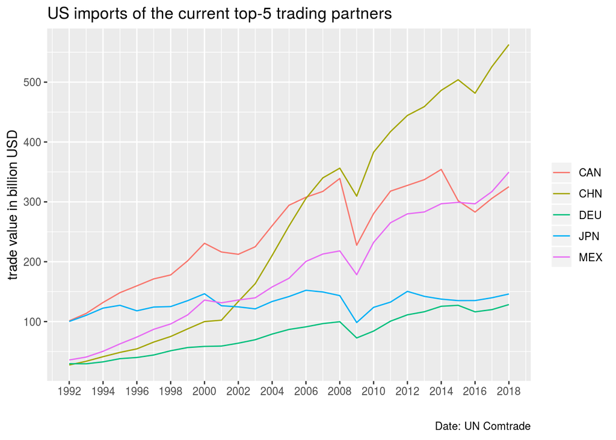

```r
top_5 <- us %>%
  filter(partner_iso != "WLD", year == 2018) %>%
  group_by(partner_iso) %>%
  tally(trade_value_usd, sort = T) %>%
  top_n(5) %>%
  pull(partner_iso)

us %>%
  filter(partner_iso %in% top_5, trade_flow == "Import") %>%
  ggplot(aes(x = year, y = billion(trade_value_usd), color = partner_iso)) +
  geom_line() +
  scale_x_continuous(breaks = seq(1992, 2018, 2)) +
  labs(title = "US imports of the current top-5 trading partners",
       x = "", y = "trade value in billion USD", color = "",
       caption = "Date: UN Comtrade")
```

It’s also interesting to view it as share of total imports.

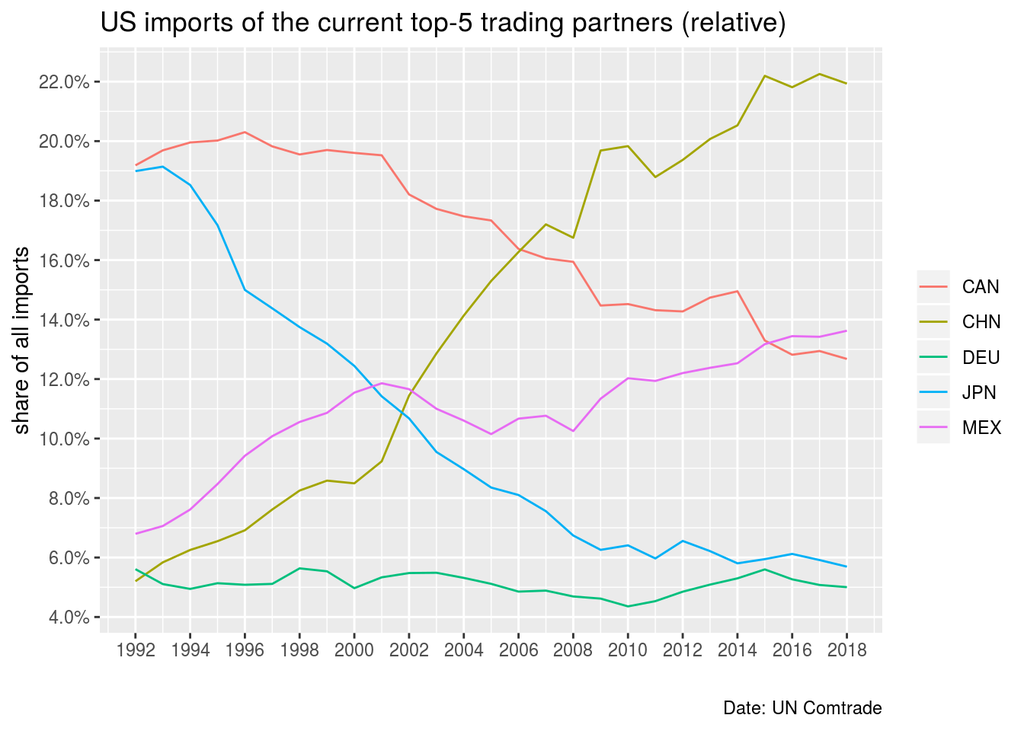

```r
top_5 <- us %>%
  filter(partner_iso != "WLD", year == 2018) %>%
  group_by(partner_iso) %>%
  tally(trade_value_usd, sort = T) %>%
  top_n(5) %>%
  pull(partner_iso)

us %>%
  filter(partner_iso != "WLD", trade_flow == "Import") %>%
  group_by(year) %>%
  mutate(share_of_total = trade_value_usd/sum(trade_value_usd)) %>%
  ungroup() %>%
  filter(partner_iso %in% top_5, trade_flow == "Import") %>%
  ggplot(aes(x = year, y = share_of_total, color = partner_iso)) +
  geom_line() +
  scale_x_continuous(breaks = seq(1992, 2018, 2)) +
  scale_y_continuous(labels = scales::percent, breaks = seq(0.04, 0.5, by = 0.02)) +
  labs(title = "US imports of the current top-5 trading partners (relative)",
       x = "", y = "share of all imports", color = "",
       caption = "Date: UN Comtrade")
```

# China international trade

How does the situation look like from the point of view of China? How much do Chinese rely on the US?

## Data

```r
ch1 <- ct_search(reporters = "China",
                 partners = "All",
                 trade_direction = c("imports", "exports"),
                 freq = "annual",
                 start_date = (2018-4),
                 end_date = 2018)

ch2 <- ct_search(reporters = "China",
                 partners = "All",
                 trade_direction = c("imports", "exports"),
                 freq = "annual",
                 start_date = (2013-4),
                 end_date = 2013)

ch3 <- ct_search(reporters = "China",
                 partners = "All",
                 trade_direction = c("imports", "exports"),
                 freq = "annual",
                 start_date = (2008-4),
                 end_date = 2008)

ch4 <- ct_search(reporters = "China",
                 partners = "All",
                 trade_direction = c("imports", "exports"),
                 freq = "annual",
                 start_date = (2003-4),
                 end_date = 2003)

ch5 <- ct_search(reporters = "China",
                 partners = "All",
                 trade_direction = c("imports", "exports"),
                 freq = "annual",
                 start_date = (1998-4),
                 end_date = 1998)

ch <- bind_rows(ch1, ch2, ch3, ch4, ch5) %>% distinct()

# ch %>% saveRDS("data/ch.RDS")
```

Note that the most recent annual data for China is 2017.

## Imports and exports

[figure not shown]

```r
trade_plot(ch, yr = 2017, top_n = 0, include_others = T, include_flags = T, include_share = F)
```

[figure not shown]

```r
trade_plot(ch, yr = 2017, top_n = 24, include_others = T, include_flags = T, include_share = T, title = "China imports and exports")
```

# Development over time

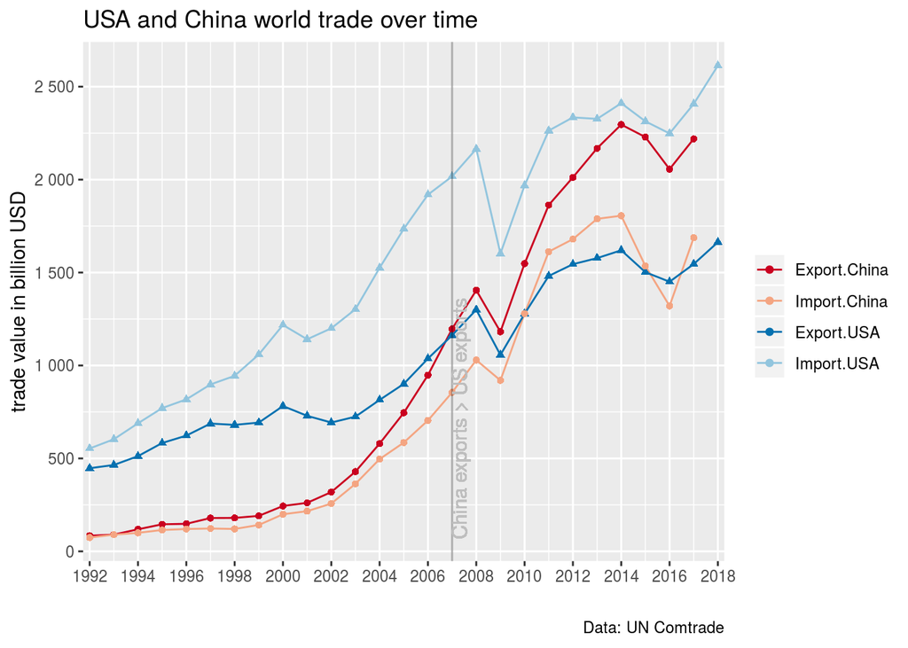

```r
# CHINA or MEXICO trade with US

data1 <- us %>% #distinct() %>%
  filter(partner_iso == "WLD") %>%
  mutate(trade_value_usd_bn = billion(trade_value_usd)) %>%
  group_by(trade_flow, year) %>%
  summarise(trade_value_usd_bn = sum(trade_value_usd_bn, na.rm = T))

# data1 %>%
#   ggplot(aes(x = year, y = trade_value_usd_bn, color = trade_flow, fill = trade_flow)) +
#   geom_area(alpha = 0.1, position = "identity") +
#   geom_point() +
#   scale_y_continuous(labels = scales::number, breaks = seq(0, 250, 50)) +
#   scale_color_manual(values = c("#88be3f", "#02a7eb")) +
#   scale_x_continuous(breaks = seq(1990, 2018, 2), expand = c(0.01, 0.01)) +
#   labs(title = "USA import and exports over time",
#        x = "", y = "trade value in billion USD", caption = "Data: UN Comtrade", color = "", fill = "")


data2 <- ch %>% #distinct() %>%
  filter(partner_iso != "WLD") %>%
  mutate(trade_value_usd_bn = billion(trade_value_usd)) %>%
  group_by(trade_flow, year) %>%
  summarise(trade_value_usd_bn = sum(trade_value_usd_bn, na.rm = T))

# data2 %>%
#   ggplot(aes(x = year, y = trade_value_usd_bn, color = trade_flow, fill = trade_flow)) +
#   geom_area(alpha = 0.1, position = "identity") +
#   geom_point() +
#   scale_y_continuous(labels = scales::number, breaks = seq(0, 2500, 500)) +
#   scale_color_manual(values = c("#88be3f", "#02a7eb")) +
#   scale_x_continuous(breaks = seq(1990, 2018, 2), expand = c(0.01, 0.01)) +
#   labs(title = "USA import and exports over time",
#        x = "", y = "trade value in billion USD", caption = "Data: UN Comtrade", color = "", fill = "")

bind_rows(
  data1 %>% mutate(reporter = "USA"),
  data2 %>% mutate(reporter = "China")
) %>%
  ggplot(aes(x = year, y = trade_value_usd_bn, color = interaction(trade_flow, reporter), fill = interaction(trade_flow, reporter))) +
  geom_line() +
  # geom_area(alpha = 0.1, position = "identity") +
  geom_point(aes(shape = reporter)) +
  geom_vline(xintercept = 2007, alpha = 0.3) +
  geom_text(label = "China exports > US exports", x = 2007, y = 0, inherit.aes = F, color = "grey",
            angle = 90, vjust = 1, hjust = -0.05) +
  scale_y_continuous(labels = scales::number, breaks = seq(0, 2500, 500)) +
  scale_color_manual(values = c("#ca0020", "#f4a582", "#0571b0", "#92c5de")) +
  scale_x_continuous(breaks = seq(1990, 2018, 2), expand = c(0.01, 0.01)) +
  scale_shape(guide = "none") +
  labs(title = "USA and China world trade over time",
       x = "", y = "trade value in billion USD", caption = "Data: UN Comtrade", color = "", fill = "")
```

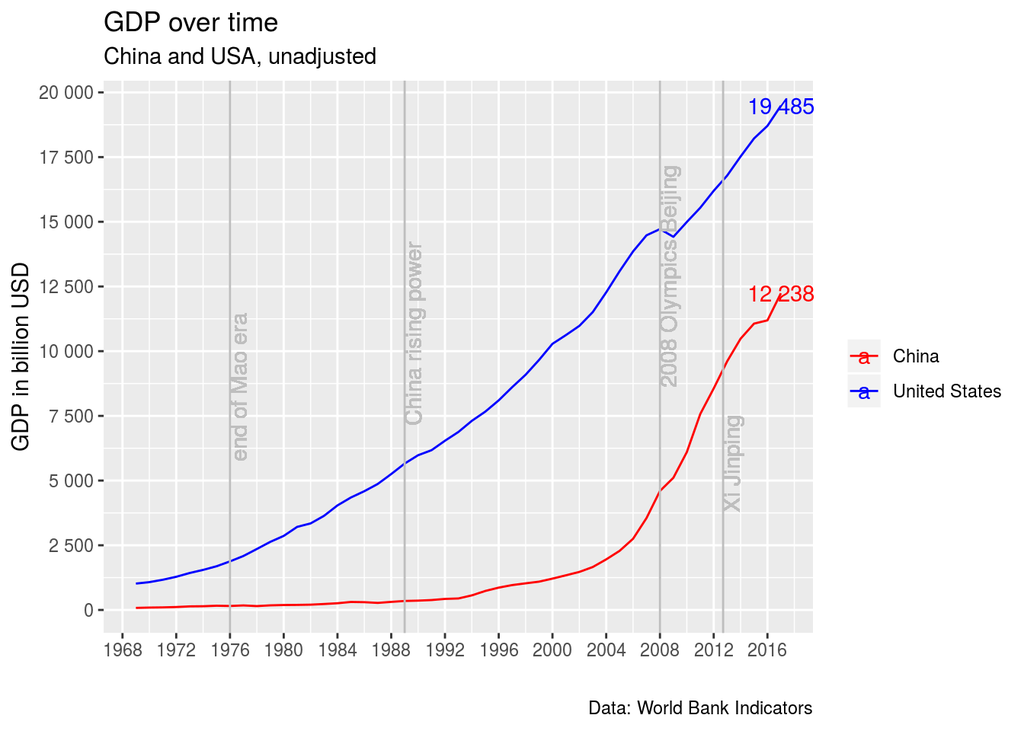

```r
# # There are libraries for loading data from World Bank Indicators, but I encountered issues.
# # Therefore we shall download data from https://databank.worldbank.org/data/reports.aspx?source=2&series=NY.GDP.MKTP.CD#
# library(WDI)
# library(wbstats)

gdp <- read_csv("data/gdp.csv")

gdp <- gdp %>%
  filter(str_detect(`Series Name`, "GDP")) %>%
  select(-`2018 [YR2018]`) %>%
  gather(year, gdp, -`Series Name`, -`Series Code`, -`Country Name`, -`Country Code`) %>%
  select(-`Series Name`, -`Series Code`) %>%
  mutate(year = str_sub(year, 1, 4) %>% as.integer(),
         gdp_label = ifelse(year == 2017, number2(billion(gdp)), ""))

gdp %>%
  ggplot(aes(x = year, y = billion(gdp), color = `Country Name`)) +
  geom_line() +
  scale_color_manual(values = c("red", "blue")) +
  scale_y_continuous(labels = scales::number, breaks = seq(0, 20000, by = 2500)) +
  scale_x_continuous(breaks = seq(1968, 2018, by = 4)) +
  geom_vline(xintercept = 1976, color = "grey") +
  geom_text(label = "end of Mao era", x = 1976, y = 0, inherit.aes = F, color = "grey",
            angle = 90, vjust = 1, hjust = -1) +
  geom_vline(xintercept = 1989, color = "grey") +
  geom_text(label = "China rising power", x = 1989, y = 0, inherit.aes = F, color = "grey",
            angle = 90, vjust = 1, hjust = -1) +
  geom_vline(xintercept = 2008, color = "grey") +
  geom_text(label = "2008 Olympics Beijing", x = 2008, y = 0, inherit.aes = F, color = "grey",
            angle = 90, vjust = 1, hjust = -1) +
  geom_vline(xintercept = 2012.7, color = "grey") +
  geom_text(label = "Xi Jinping", x = 2012.7, y = 0, inherit.aes = F, color = "grey",
            angle = 90, vjust = 1, hjust = -1) +
  geom_text(aes(label = gdp_label)) +
  labs(title = "GDP over time",
       subtitle = "China and USA, unadjusted",
       x = "", y = "GDP in billion USD",
       color = "",
       caption = "Data: World Bank Indicators")
```

# A look at the goods

What goods do the USA import from China?

```r
com1 <- tibble()

for (i in 0:4) {
  codes <- c(1:20) + i*20

  com1 <- com1 %>%
    bind_rows(ct_search(reporters = "USA",
                        partners = "China",
                        start_date = "2018",
                        end_date = "2018",
                        trade_direction = c("imports", "exports"),
                        commod_codes = str_pad(codes, 2, "left", "0")))

  print("sleep 10 secs")
  Sys.sleep(10)
}

com %>% saveRDS("data/com.RDS")
```

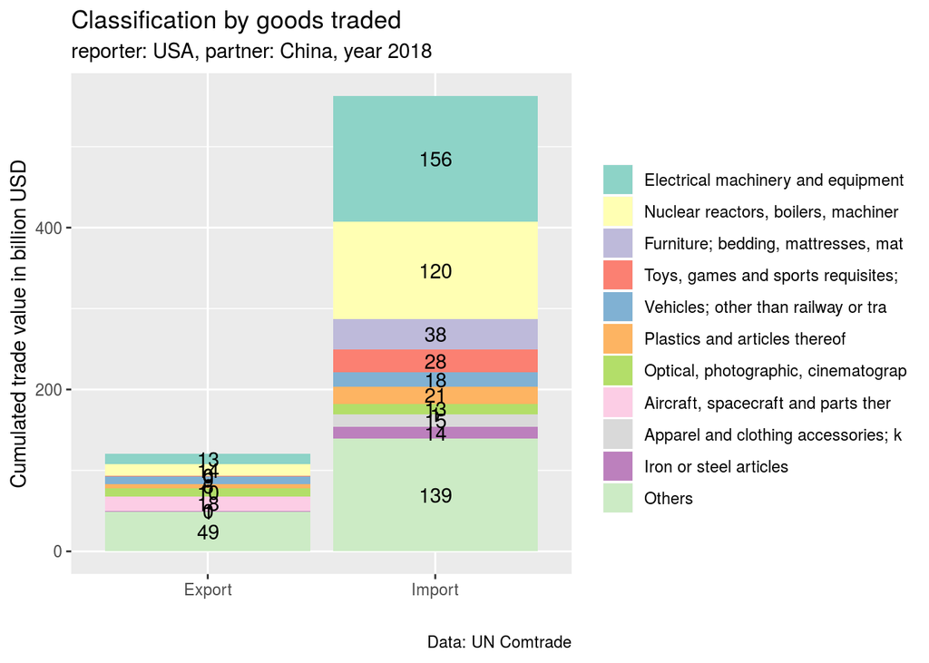

```r
top_com <- com %>%
  group_by(commodity) %>%
  tally(trade_value_usd, sort = T) %>%
  top_n(10) %>%
  pull(commodity)

others <- com %>%
  filter(!(commodity %in% top_com)) %>%
  group_by(trade_flow) %>%
  summarise(trade_value_usd = sum(trade_value_usd)) %>%
  mutate(commodity = "Others")

com %>%
  filter(commodity %in% top_com) %>%
  bind_rows(others) %>%
  mutate(trade_value_usd_bn = billion(trade_value_usd)) %>%
  select(trade_flow, trade_value_usd_bn, commodity) %>%
  # arrange(-trade_value_usd) %>%
  ggplot(aes(y = trade_value_usd_bn, x = trade_flow,  fill = factor(str_sub(commodity, 1, 35), levels = str_sub(c(top_com, "Others"), 1, 35)))) +
  geom_col() +
  geom_text(aes(label = number(trade_value_usd_bn)), position = position_stack(vjust = .5)) +
  scale_fill_brewer(palette = "Set3") +
  scale_y_continuous(labels = scales::number) +
  labs(title = "Classification by goods traded",
       subtitle = "reporter: USA, partner: China, year 2018",
       x = "", y = "Cumulated trade value in billion USD",
       fill = "",
       caption = "Data: UN Comtrade")
```

# Extras

## Network graph

Let’s make a [visNetwork](https://datastorm-open.github.io/visNetwork/) graph.

```r
data <- us %>% filter(year == 2018, partner != "World")

edges <- bind_rows(
  # exports
  data %>%
    filter(trade_flow == "Export") %>%
    select(from = reporter, to = partner, value = trade_value_usd) %>%
    arrange(desc(value)),

  # imports
  data %>%
    filter(trade_flow == "Import") %>%
    select(from = partner, to = reporter, value = trade_value_usd) %>%
    arrange(desc(value))
) %>%
  mutate(title = paste0("bn$", number(value/1000000000)))

cutoff <- 38000000000

nodes <- bind_rows(
  edges %>%
    filter(value >= cutoff) %>%
    select(id = from),
  edges %>%
    filter(value >= cutoff) %>%
    select(id = to)
) %>%
  unique() %>%
  left_join(data %>% filter(year == 2018) %>% select(id = partner, label = partner_iso) %>% unique()) %>%
  mutate(shape = "circularImage", image = paste0("./flags/", str_replace_all(id, " ", "_"), ".png"))

visNetwork(nodes, edges, width = "100%") %>%
  visEdges(arrows = "from")
```

[interactive chart not shown]